# Predation

### Grazing sheep and functional responses

If I were placed in a room with 1 slice of pizza, I may eat a different amount of pizza than if you put me in a room with 5 pizzas. The example in the book is of grazing sheep, but I like pizza. They argue that to best maintain the grass resources and to know how many sheep can graze a given area, we have to know two things; the rate of consumption of the resource by the sheep as a function of the amount of resource (the functional response), and the rate at which the grass grows. In the case of the pizza, we can imagine that I would have no trouble finding pizza in a room filled with pizza, and my consumption rate would likely be high. If pizza were scarce and not clearly labeled, I woudld have to search for pizza, lowering my consumption rate (lower part of curves in Figure 10.1). However, there is an upper limit to the rate that pizza may be consumed, so if more pizza were added, I would still eat at the same rate.

### Dynamics of the resource population under exploitation

In the room of pizza example we don’t necessarily expect a continuous stream of pizza coming into the room, but in many consumer systems, the resource will replace itself (e.g., grass growing in a field). We can model this growth like we did previously using something like the logistic model, where grass will grow up until it reaches a carrying capacity $K$ in the absence of consumption.

The consumer and the resource have inherently coupled dynamics, as the resource is consumed, and the consumer turns this resource into more consumers. This influences the equilibria of the system as a function of consumers((Go over Fig 10.4 and Fig 10.7 and Fig 10.9))

### Harvesting fisheries

$$N_{t+1} = rN_t \dfrac{K-N_t}{K} - L$$

where $r$ is population growth rate, $K$ is carrying capacity, and $L$ is the total removal of fish per time $t$, where $t$ is in terms of the entire fishing season (which hopefully maps well onto the fish reproduction and generation times).

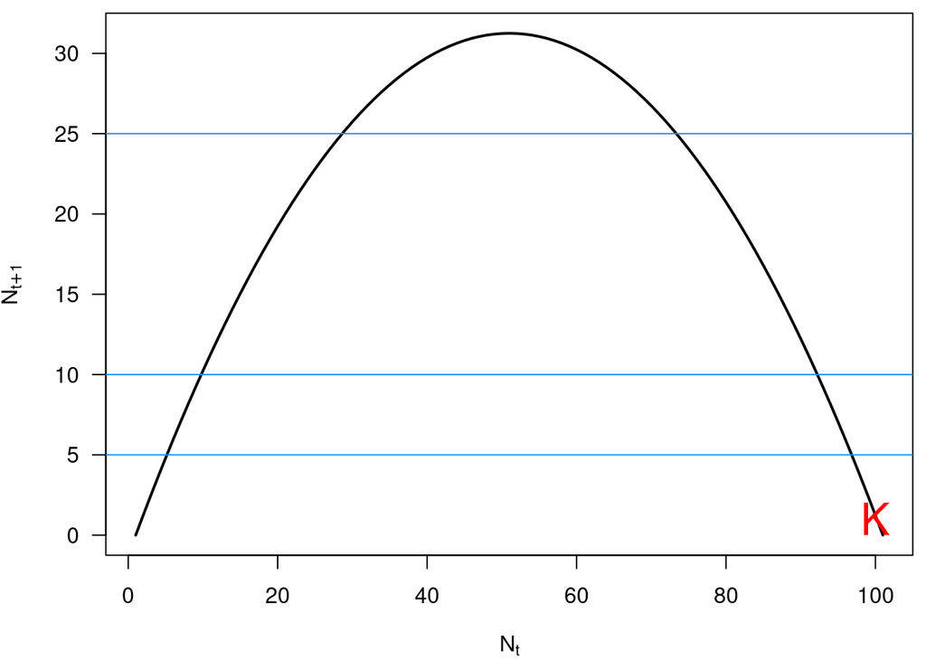

```r
logisticGrowth <- function(N, r=1.25, K=100){
  ret <- r*N * ((K-N)/K)
  return(ret)
}

par(mar=c(4,4,0.5,0.5))
plot(logisticGrowth(0:100), lwd=2,
  ylab=expression(N[t+1]),
  xlab=expression(N[t]), type='l', las=1)
points(100,1, cex=2, pch='K', col='red')

abline(h=5, col='dodgerblue')
abline(h=10, col='dodgerblue')
abline(h=25, col='dodgerblue')
```

The above is the ‘fixed quota’ example, where fish are removed at some constant limit $Q$. But when fish are scarce, they are harder to find, such that fishing is inherently linked to population size and effort. If we set quotas $Q$ based on effort rather than total fish, we can start to see different relationships.

$$L = (fishing effort)(C)(N)$$

where $C$ is the ‘catchability’ of fish, in units of number of fish per unit effort per fish (we will treat this as a constant).

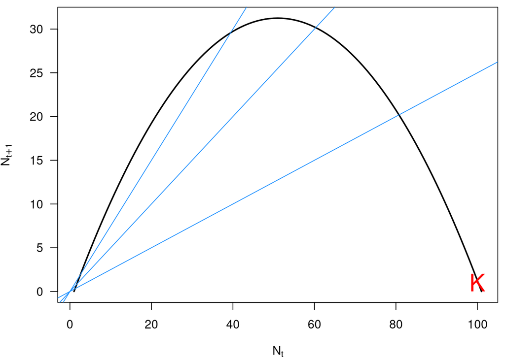

```r
par(mar=c(4,4,0.5,0.5))
plot(logisticGrowth(0:100), lwd=2,
  ylab=expression(N[t+1]),
  xlab=expression(N[t]), type='l', las=1)
points(100,1, cex=2, pch='K', col='red')

abline(b=0.75, a=0, col='dodgerblue')
abline(b=0.5, a=0, col='dodgerblue')
abline(b=0.25, a=0, col='dodgerblue')
```

Regulation as a function of effort can produce an estimate of maximum sustainable yield, as where those effort lines hit the population curve are the number of fish caught given that effort. Placing ‘effort’ as the x-axis and number of fish caught as the y-axis, we may want to select the maximum fish caught per catch from that effort. What are some theoretical considerations to keep in mind here? How does this play out with the Peruvian anchovy example (Figure 10.17)?

In the logistic model, we can calculate the MSY as $K/2$, as this is the peak of the hump in terms of population growth rate (maximal production). Plugging $K/2$ in for $dN/dt$ in the logistic model yields a MSY of $\dfrac{rK}{4}$ (see Figure 10.19). Why is this perhaps an untenable amount of effort?

> Figure 10.23 should get you excited about Chapter 12, as it starts to recognize that the prey population is growing as well, introducing the equilibrium as a line in phase space between predator and prey, as these two groups are intrinsically linked, such that the equilibrium of one is always dependent on the abundance of the other. Get excited for that.

One interesting idea is that if we have information on catchability, effort, and resource levels, we can estimate demographic parameters like $r$ and $K$ under harvesting scenarios (or *in terms* of harvesting parameters). For instance,

$$\dfrac{rK}{4} = (C)(effort)(K/2)$$

allows us to solve for $r$ and $K$, where

$$r = 2(C)(effort)$$

and

$$K = \dfrac{4(MSY)}{2(C)(effort)}$$

But all this assumes the logistic model describes demography well, and ignores of important bits. For instance, we talked about Allee effects briefly before. What happens if there is an Allee effect in the resouce population in a fixed harvesting scenario (Figure 10.27)?

## The mechanics of predation

### The disk equation

We introduced predation by talking about me in a room of pizza or sheep grazing on grass. It was overly simplistic, as it ignores lots of neat bits about consumer-resource relationships. Let’s dive into the muckiness of consumer-resource modeling. For instance, let’s start by considering that the predator has to find the prey. So,

the number of prey encountered = detectability * area searched * prey per unit area

We can already start to imagine how these different parameter would affect the resulting number of prey consumed (or even encountered), as detectability could be a function of visual acuity or range. Area searched could vary strongly by consumer body size, and prey per unit area tends to assume a random distribution of prey, when random distributions are not typically all that commonly observed. Putting the observed notation in mathematical notation, we can consider the number of prey encountered $V_a$ as a function of prey encounter rate $a$, search duration $T_s$ and prey density $V$.

$$V_a = a T_s V$$

$$V_a = \dfrac{aVT_t}{1 + aT_hV}$$

named because it is based on a ‘moving disk’ representing the predators sensory field. From this equation, we can calculate the predator functional response (number of prey captured per predator per unit time), as

$$B(V) = \dfrac{V_a(V)}{T_t} =
\dfrac{aV}{1+aT_hV}$$

where $B(V)$ indicates that the functional response is a function of prey density $V$. The maximal consumption rate is $\frac{1}{T_h}$, which we can show by dividing both sides of the equation above by $aV$ and imaging the situation where $V$ goes to infinity (i.e., there is no resource limitation). This is shown graphically in Figure 11.3. Modifying the handling time $T_h$ can produce different functional response shapes. For instance, in the case where handling time is 0 ($T_h = 0$), we get a linear functional response (as the predator can instantly consume prey, so it is only limited by prey encounter). This looks like

$$B(V) = \dfrac{1}{1/aV} = aV$$

where the prey encounter rate $a$ is the slope of the linear functional response (Figure 11.5). The type 2 functional response includes handling time, and is the ‘typical’ case (Figure 11.3). We can also imagine a situation where encounter rate $a$ is a function of the prey density $V$. This would be the situation where at low prey densities, prey become harder to find (e.g., there are fixed number of prey ‘hiding spots’).

$$B(V) = \dfrac{V_a(V)}{T_t} =
\dfrac{aVV}{1+aVT_hV} = \dfrac{aV^{2}}{1+aT_hV^{2}}$$

These 3 functional responses are the most typical considered (Case goes into one other in the text, but we won’t cover it here). This can be viewed in terms of prey consumption rates ($B(V)$) as well as the individual prey consumption risk ($B(V)/V$), showing the relative risk of predation as a function of $V$ (Figure 11.9).

### Multiple prey items

We couldn’t just have it be simple, right? Consumers do not often only consume a single resource, but instead may contain any number of resources, which vary in their densities $V_1, V_2, V_3,...V_n$. We now define $\mathbf{V}$ as this vector of prey densities, using the same functional response equation as before with some minor tweaks.

$$B_i(\mathbf{V}) = \dfrac{a_i(V_i)V_i}{1
+ \sum a_j(V_j)V_jT_{hj}}$$

where the functional response for prey $i$ is a function of the availability of other prey items $j$. In the case of the functional responses we have covered, a higher prey encounter rate $a_i$ will lead to the predator disportionately consuming prey $i$, right? Such that the important bits about prey density are the relative abundance of the prey items $i$, not absolute densities. But this does not include prey preference. If I am in a room equally filled with pizza and carrots, I may encounter these two items at the same rate, but I am sure not eating them in equal proportion. We can visualize this by plotting the percent of a prey item in the environment against the percent of a prey item in the actual diet of the predator (Figure 11.13). The preferences of the predator, at least in terms of the percent of prey item $i$ in the predator diet, may change as a function of the availability of the prey item (Figure 11.14 and Figure 11.15). This happens only for the type 3 functional response. Why?